# LOS ANGELES DODGERS Report on Bobblehead Distribution's Effect on Fan Attendance

## **MODEL SELECTION & FULL REGRESSION ANALYSIS**

We created a finer data model by utilizing the analysis held in the above section to better understand fans' attendance to the games according to different variables. Below part covers consecutive process of deciding the best model that we came up. By carrying out anova analysis Adj R2, F-test, and AIC values are compared repetitively. According to analysis results, useful variables are determined and added to our model. Finally, diagnostic plots are displayed and further predictions are added.

```python
model1 = sm.formula.ols('attend ~ month*day_of_week + bobblehead + temp', data=events).fit()
print(model1.summary())
```

```
                            OLS Regression Results
==============================================================================
Dep. Variable:                 attend   R-squared:                       0.808
Model:                            OLS   Adj. R-squared:                  0.561
Method:                 Least Squares   F-statistic:                     3.275
Date:                Sun, 23 Apr 2023   Prob (F-statistic):           0.000227
Time:                        17:20:51   Log-Likelihood:                -778.49
No. Observations:                  81   AIC:                             1649.
Df Residuals:                      35   BIC:                             1759.
Df Model:                          45
Covariance Type:            nonrobust
=========================================================================================================
                                            coef    std err          t      P>|t|      [0.025      0.975]
---------------------------------------------------------------------------------------------------------
Intercept                              2.112e+04   7896.782      2.674      0.011    5084.060    3.71e+04
month[T.MAY]                           7280.0864   6601.980      1.103      0.278   -6122.645    2.07e+04
month[T.JUN]                           2.268e+04   7938.540      2.857      0.007    6563.874    3.88e+04
month[T.JUL]                           5048.8738   6660.748      0.758      0.454   -8473.164    1.86e+04
month[T.AUG]                           4728.8539   7803.528      0.606      0.548   -1.11e+04    2.06e+04
month[T.SEP]                           2654.8970   9166.458      0.290      0.774    -1.6e+04    2.13e+04
month[T.OCT]                           2363.1385   9387.556      0.252      0.803   -1.67e+04    2.14e+04
day_of_week[T.Tuesday]                 2.269e+04   6806.011      3.334      0.002    8874.666    3.65e+04
day_of_week[T.Wednesday]               1473.1207   6733.294      0.219      0.828   -1.22e+04    1.51e+04
day_of_week[T.Thursday]                2515.6379   7795.138      0.323      0.749   -1.33e+04    1.83e+04
day_of_week[T.Friday]                  1.183e+04   6730.247      1.757      0.088   -1835.128    2.55e+04
day_of_week[T.Saturday]                1.743e+04   6983.811      2.495      0.017    3249.367    3.16e+04
day_of_week[T.Sunday]                   1.54e+04   6999.894      2.199      0.035    1184.607    2.96e+04
bobblehead[T.YES]                      1.168e+04   3653.352      3.197      0.003    4264.752    1.91e+04
month[T.MAY]:day_of_week[T.Tuesday]   -2.291e+04   8460.071     -2.708      0.010   -4.01e+04   -5731.898
month[T.JUN]:day_of_week[T.Tuesday]   -2.928e+04   1.11e+04     -2.641      0.012   -5.18e+04   -6775.743
month[T.JUL]:day_of_week[T.Tuesday]   -1.346e+04   8225.156     -1.637      0.111   -3.02e+04    3233.735
month[T.AUG]:day_of_week[T.Tuesday]   -1.325e+04   9625.788     -1.377      0.177   -3.28e+04    6287.592
month[T.SEP]:day_of_week[T.Tuesday]   -1.449e+04   1.05e+04     -1.377      0.177   -3.58e+04    6869.914
month[T.OCT]:day_of_week[T.Tuesday]   -1.328e+04   1.04e+04     -1.276      0.210   -3.44e+04    7849.439
month[T.MAY]:day_of_week[T.Wednesday] -7257.0000   8394.093     -0.865      0.393   -2.43e+04    9783.914
month[T.JUN]:day_of_week[T.Wednesday] -8350.2414   1.03e+04     -0.812      0.423   -2.92e+04    1.25e+04
month[T.JUL]:day_of_week[T.Wednesday]  1.105e+04   8433.099      1.310      0.199   -6073.785    2.82e+04
month[T.AUG]:day_of_week[T.Wednesday]  1740.6925   8397.418      0.207      0.837   -1.53e+04    1.88e+04
month[T.SEP]:day_of_week[T.Wednesday]  1.686e+04   1.04e+04      1.620      0.114   -4266.370     3.8e+04
month[T.OCT]:day_of_week[T.Wednesday]  -331.6036   1.03e+04     -0.032      0.975   -2.13e+04    2.06e+04
```

[output cut: 21 more lines]

```
month[T.AUG]:day_of_week[T.Sunday]    -8432.3450   8803.625     -0.958      0.345   -2.63e+04    9439.964
month[T.SEP]:day_of_week[T.Sunday]    -1.574e+04   9276.964     -1.697      0.099   -3.46e+04    3093.483
month[T.OCT]:day_of_week[T.Sunday]             0          0        nan        nan           0           0
temp                                    338.1827    364.572      0.928      0.360    -401.939    1078.304
==============================================================================
Omnibus:                        5.014   Durbin-Watson:                   2.585
Prob(Omnibus):                  0.082   Jarque-Bera (JB):                6.988
Skew:                          -0.015   Prob(JB):                       0.0304
Kurtosis:                       4.439   Cond. No.                     8.13e+17
==============================================================================

Notes:
[1] Standard Errors assume that the covariance matrix of the errors is correctly specified.
[2] The smallest eigenvalue is 6.67e-32. This might indicate that there are
strong multicollinearity problems or that the design matrix is singular.
```

```python
model1_no_temp = sm.formula.ols('attend ~ month*day_of_week + bobblehead', data=events).fit()

# Perform ANOVA test
anova_results = anova_lm(model1_no_temp, model1)

# Print the ANOVA table
print(anova_results)
```

```
   df_resid           ssr  df_diff       ss_diff         F    Pr(>F)
0      36.0  1.082896e+09      0.0           NaN       NaN       NaN
1      35.0  1.056912e+09      1.0  2.598399e+07  0.860469  0.359961
```

We also perform anova test to the model to see if `temp` is a significant variable. However, p-value is not small and we cannot reject small model. Therefore, we reject `temp` variable in our model.

Next, we add `skies` variable to our model. P-value under F-statistic is small, thus this model holds. Also, AIC value is lower than the previous model.

```python
model2 = sm.formula.ols('attend ~ month * (skies + day_of_week) + bobblehead', data=events).fit()

print(model2.summary())
```

```
                            OLS Regression Results
==============================================================================
Dep. Variable:                 attend   R-squared:                       0.869
Model:                            OLS   Adj. R-squared:                  0.662
Method:                 Least Squares   F-statistic:                     4.201
Date:                Sun, 23 Apr 2023   Prob (F-statistic):           2.99e-05
Time:                        17:04:15   Log-Likelihood:                -763.00
No. Observations:                  81   AIC:                             1626.
Df Residuals:                      31   BIC:                             1746.
Df Model:                          49
Covariance Type:            nonrobust
=========================================================================================================
                                            coef    std err          t      P>|t|      [0.025      0.975]
---------------------------------------------------------------------------------------------------------
Intercept                              3.299e+04   6324.989      5.216      0.000    2.01e+04    4.59e+04
month[T.MAY]                           2359.0038   6910.651      0.341      0.735   -1.17e+04    1.65e+04
month[T.JUN]                           1.757e+04   7953.637      2.209      0.035    1349.455    3.38e+04
month[T.JUL]                            315.6705   6910.651      0.046      0.964   -1.38e+04    1.44e+04
month[T.AUG]                           1780.5038   7185.604      0.248      0.806   -1.29e+04    1.64e+04
month[T.SEP]                           -951.4962   9906.696     -0.096      0.924   -2.12e+04    1.93e+04
month[T.OCT]                            636.0038   7953.637      0.080      0.937   -1.56e+04    1.69e+04
skies[T.Cloudy]                       -6611.9962   4092.753     -1.616      0.116    -1.5e+04    1735.228
day_of_week[T.Tuesday]                 2.033e+04   6250.595      3.252      0.003    7576.829    3.31e+04
day_of_week[T.Wednesday]               1661.0000   5906.123      0.281      0.780   -1.04e+04    1.37e+04
day_of_week[T.Thursday]                1952.0000   6819.803      0.286      0.777    -1.2e+04    1.59e+04
day_of_week[T.Friday]                  8522.0019   6250.595      1.363      0.183   -4226.171    2.13e+04
day_of_week[T.Saturday]                1.419e+04   6324.989      2.243      0.032    1289.097    2.71e+04
day_of_week[T.Sunday]                  1.057e+04   7185.604      1.471      0.151   -4087.133    2.52e+04
bobblehead[T.YES]                      1.305e+04   3350.594      3.895      0.000    6215.429    1.99e+04
month[T.MAY]:skies[T.Cloudy]           5630.2462   5847.373      0.963      0.343   -6295.549    1.76e+04
month[T.JUN]:skies[T.Cloudy]          -1.102e+04   5948.400     -1.853      0.073   -2.32e+04    1110.834
month[T.JUL]:skies[T.Cloudy]          -8745.5785   6303.823     -1.387      0.175   -2.16e+04    4111.153
month[T.AUG]:skies[T.Cloudy]           1.292e+04   7953.637      1.624      0.115   -3305.553    2.91e+04
month[T.SEP]:skies[T.Cloudy]           8115.4962   7185.604      1.129      0.267   -6539.641    2.28e+04
month[T.OCT]:skies[T.Cloudy]           2670.4981   4953.348      0.539      0.594   -7431.922    1.28e+04
month[T.MAY]:day_of_week[T.Tuesday]    -2.07e+04   7877.658     -2.628      0.013   -3.68e+04   -4633.753
month[T.JUN]:day_of_week[T.Tuesday]   -1.102e+04   5948.400     -1.853      0.073   -2.32e+04    1110.834
month[T.JUL]:day_of_week[T.Tuesday]   -1001.9559   8012.233     -0.125      0.901   -1.73e+04    1.53e+04
month[T.AUG]:day_of_week[T.Tuesday]   -1.263e+04   8791.669     -1.437      0.161   -3.06e+04    5300.214
month[T.SEP]:day_of_week[T.Tuesday]   -1.174e+04    1.1e+04     -1.070      0.293   -3.41e+04    1.06e+04
```

[output cut: 27 more lines]

```
month[T.JUL]:day_of_week[T.Sunday]    -2859.1762   8806.858     -0.325      0.748   -2.08e+04    1.51e+04
month[T.AUG]:day_of_week[T.Sunday]    -3135.5038   8653.772     -0.362      0.720   -2.08e+04    1.45e+04
month[T.SEP]:day_of_week[T.Sunday]    -8281.8372   1.08e+04     -0.764      0.451   -3.04e+04    1.38e+04
month[T.OCT]:day_of_week[T.Sunday]             0          0        nan        nan           0           0
==============================================================================
Omnibus:                       12.661   Durbin-Watson:                   2.508
Prob(Omnibus):                  0.002   Jarque-Bera (JB):               24.552
Skew:                          -0.503   Prob(JB):                     4.66e-06
Kurtosis:                       5.503   Cond. No.                     1.18e+16
==============================================================================

Notes:
[1] Standard Errors assume that the covariance matrix of the errors is correctly specified.
[2] The smallest eigenvalue is 8.09e-31. This might indicate that there are
strong multicollinearity problems or that the design matrix is singular.
```

```python
model2_no_sky = sm.formula.ols('attend ~ month * day_of_week + bobblehead', data=events).fit()

# Perform ANOVA test
anova_results = anova_lm(model2_no_sky, model2)

# Print the ANOVA table
print(anova_results)
```

```
   df_resid           ssr  df_diff       ss_diff         F    Pr(>F)
0      36.0  1.082896e+09      0.0           NaN       NaN       NaN
1      31.0  7.209006e+08      5.0  3.619953e+08  3.113288  0.021641
```

We apply anova test to the model for `skies` variable. Here, p-value is small, hence we reject small model (i.e. `skies` is a significant variable).

```python
model3 = sm.formula.ols('attend ~ month * (skies + day_of_week) + bobblehead + day', data=events).fit()

print(model3.summary())
```

```
                            OLS Regression Results
==============================================================================
Dep. Variable:                 attend   R-squared:                       0.869
Model:                            OLS   Adj. R-squared:                  0.651
Method:                 Least Squares   F-statistic:                     3.986
Date:                Sun, 23 Apr 2023   Prob (F-statistic):           6.28e-05
Time:                        17:04:15   Log-Likelihood:                -762.98
No. Observations:                  81   AIC:                             1628.
Df Residuals:                      30   BIC:                             1750.
Df Model:                          50
Covariance Type:            nonrobust
=========================================================================================================
                                            coef    std err          t      P>|t|      [0.025      0.975]
---------------------------------------------------------------------------------------------------------
Intercept                              3.279e+04   6712.332      4.885      0.000    1.91e+04    4.65e+04
month[T.MAY]                           2424.7088   7053.656      0.344      0.733    -1.2e+04    1.68e+04
month[T.JUN]                           1.768e+04   8153.993      2.168      0.038    1026.377    3.43e+04
month[T.JUL]                            384.0219   7056.113      0.054      0.957    -1.4e+04    1.48e+04
month[T.AUG]                           1872.6733   7359.756      0.254      0.801   -1.32e+04    1.69e+04
month[T.SEP]                           -613.2068   1.06e+04     -0.058      0.954   -2.23e+04    2.11e+04
month[T.OCT]                            823.4455   8293.383      0.099      0.922   -1.61e+04    1.78e+04
skies[T.Cloudy]                       -6599.2202   4161.614     -1.586      0.123   -1.51e+04    1899.929
day_of_week[T.Tuesday]                 2.038e+04   6375.243      3.197      0.003    7359.043    3.34e+04
day_of_week[T.Wednesday]               1700.6968   6015.541      0.283      0.779   -1.06e+04     1.4e+04
day_of_week[T.Thursday]                2039.3329   6984.912      0.292      0.772   -1.22e+04    1.63e+04
day_of_week[T.Friday]                  8552.2080   6359.848      1.345      0.189   -4436.335    2.15e+04
day_of_week[T.Saturday]                1.425e+04   6454.563      2.207      0.035    1065.699    2.74e+04
day_of_week[T.Sunday]                  1.059e+04   7306.008      1.449      0.158   -4332.139    2.55e+04
bobblehead[T.YES]                      1.298e+04   3480.660      3.728      0.001    5867.733    2.01e+04
month[T.MAY]:skies[T.Cloudy]           5534.1070   6018.528      0.920      0.365   -6757.368    1.78e+04
month[T.JUN]:skies[T.Cloudy]          -1.102e+04   6045.704     -1.823      0.078   -2.34e+04    1325.008
month[T.JUL]:skies[T.Cloudy]          -8785.1840   6418.885     -1.369      0.181   -2.19e+04    4323.927
month[T.AUG]:skies[T.Cloudy]           1.307e+04   8225.744      1.589      0.123   -3729.264    2.99e+04
month[T.SEP]:skies[T.Cloudy]           7935.9938   7515.623      1.056      0.299   -7412.957    2.33e+04
month[T.OCT]:skies[T.Cloudy]           2636.3224   5045.692      0.522      0.605   -7668.355    1.29e+04
month[T.MAY]:day_of_week[T.Tuesday]   -2.071e+04   8007.609     -2.587      0.015   -3.71e+04   -4360.038
month[T.JUN]:day_of_week[T.Tuesday]   -1.102e+04   6045.704     -1.823      0.078   -2.34e+04    1325.008
month[T.JUL]:day_of_week[T.Tuesday]   -1021.7587   8145.640     -0.125      0.901   -1.77e+04    1.56e+04
month[T.AUG]:day_of_week[T.Tuesday]   -1.262e+04   8936.117     -1.412      0.168   -3.09e+04    5630.331
month[T.SEP]:day_of_week[T.Tuesday]   -1.197e+04   1.14e+04     -1.052      0.301   -3.52e+04    1.13e+04
```

[output cut: 28 more lines]

```
month[T.AUG]:day_of_week[T.Sunday]    -3176.0675   8804.455     -0.361      0.721   -2.12e+04    1.48e+04
month[T.SEP]:day_of_week[T.Sunday]    -8572.4904   1.14e+04     -0.753      0.457   -3.18e+04    1.47e+04
month[T.OCT]:day_of_week[T.Sunday]             0          0        nan        nan           0           0
day                                       7.9394     78.485      0.101      0.920    -152.348     168.227
==============================================================================
Omnibus:                       12.684   Durbin-Watson:                   2.512
Prob(Omnibus):                  0.002   Jarque-Bera (JB):               25.106
Skew:                          -0.494   Prob(JB):                     3.53e-06
Kurtosis:                       5.542   Cond. No.                     1.16e+16
==============================================================================

Notes:
[1] Standard Errors assume that the covariance matrix of the errors is correctly specified.
[2] The smallest eigenvalue is 2.11e-28. This might indicate that there are
strong multicollinearity problems or that the design matrix is singular.
```

We add `day` variable to our model. P-value under F-statistic is small, thus this model holds. However, AIC value is higher than the previous model.

```python
# Perform ANOVA test
anova_results = anova_lm(model2, model3)

# Print the ANOVA table
print(anova_results)
```

```
   df_resid           ssr  df_diff        ss_diff         F    Pr(>F)
0      31.0  7.209006e+08      0.0            NaN       NaN       NaN
1      30.0  7.206548e+08      1.0  245812.504931  0.010233  0.920098
```

P-value is not small. Hence, we cannot reject small model and `day` is excluded from our model.

```python
model4 = sm.formula.ols('attend ~ month * (skies + day_of_week) + bobblehead + opponent', data=events).fit()
print(model4.summary())
```

```
                            OLS Regression Results
==============================================================================
Dep. Variable:                 attend   R-squared:                       0.936
Model:                            OLS   Adj. R-squared:                  0.713
Method:                 Least Squares   F-statistic:                     4.211
Date:                Sun, 23 Apr 2023   Prob (F-statistic):           0.000693
Time:                        17:04:15   Log-Likelihood:                -734.33
No. Observations:                  81   AIC:                             1595.
Df Residuals:                      18   BIC:                             1746.
Df Model:                          62
Covariance Type:            nonrobust
=========================================================================================================
                                            coef    std err          t      P>|t|      [0.025      0.975]
---------------------------------------------------------------------------------------------------------
Intercept                              3.351e+04   4645.594      7.213      0.000    2.38e+04    4.33e+04
month[T.MAY]                            314.7128   4480.066      0.070      0.945   -9097.556    9726.982
month[T.JUN]                           1.705e+04   5349.624      3.187      0.005    5808.895    2.83e+04
month[T.JUL]                           3853.7408   4345.047      0.887      0.387   -5274.865     1.3e+04
month[T.AUG]                          -1752.9621   4658.912     -0.376      0.711   -1.15e+04    8035.048
month[T.SEP]                            240.2362   6957.325      0.035      0.973   -1.44e+04    1.49e+04
month[T.OCT]                          -4856.7908   5770.255     -0.842      0.411    -1.7e+04    7266.065
skies[T.Cloudy]                         308.1374   5941.067      0.052      0.959   -1.22e+04    1.28e+04
day_of_week[T.Tuesday]                 1.987e+04   6061.565      3.277      0.004    7130.659    3.26e+04
day_of_week[T.Wednesday]              -2258.5344   6061.565     -0.373      0.714    -1.5e+04    1.05e+04
day_of_week[T.Thursday]               -5887.0687   8248.005     -0.714      0.485   -2.32e+04    1.14e+04
day_of_week[T.Friday]                  2102.1736   3906.550      0.538      0.597   -6105.183    1.03e+04
day_of_week[T.Saturday]                7247.4331   4218.404      1.718      0.103   -1615.106    1.61e+04
day_of_week[T.Sunday]                  7608.2423   3899.509      1.951      0.067    -584.322    1.58e+04
bobblehead[T.YES]                      1.409e+04   4235.662      3.327      0.004    5193.686     2.3e+04
opponent[T.Astros]                    -1.132e+04   5808.715     -1.948      0.067   -2.35e+04     887.428
opponent[T.Braves]                    -7443.0988   6121.499     -1.216      0.240   -2.03e+04    5417.694
opponent[T.Brewers]                    2689.2290   3854.282      0.698      0.494   -5408.316    1.08e+04
opponent[T.Cardinals]                  2833.3685   3283.487      0.863      0.400   -4064.982    9731.719
opponent[T.Cubs]                       2033.9190   5812.736      0.350      0.730   -1.02e+04    1.42e+04
opponent[T.Giants]                     4969.8294   3205.316      1.550      0.138   -1764.290    1.17e+04
opponent[T.Marlins]                    -126.0810   5819.018     -0.022      0.983   -1.24e+04    1.21e+04
opponent[T.Mets]                       1018.8496   5709.251      0.178      0.860    -1.1e+04     1.3e+04
opponent[T.Nationals]                  5406.2619   5525.888      0.978      0.341   -6203.198     1.7e+04
opponent[T.Padres]                     -532.6694   3588.353     -0.148      0.884   -8071.520    7006.181
opponent[T.Phillies]                  -3920.0128   4831.433     -0.811      0.428   -1.41e+04    6230.452
```

[output cut: 43 more lines]

```
month[T.JUL]:day_of_week[T.Sunday]    -4725.2752   5608.485     -0.843      0.411   -1.65e+04    7057.715
month[T.AUG]:day_of_week[T.Sunday]     1880.8393   7862.773      0.239      0.814   -1.46e+04    1.84e+04
month[T.SEP]:day_of_week[T.Sunday]    -7299.9264   5686.519     -1.284      0.216   -1.92e+04    4647.007
month[T.OCT]:day_of_week[T.Sunday]             0          0        nan        nan           0           0
==============================================================================
Omnibus:                        6.379   Durbin-Watson:                   2.896
Prob(Omnibus):                  0.041   Jarque-Bera (JB):                8.566
Skew:                          -0.274   Prob(JB):                       0.0138
Kurtosis:                       4.496   Cond. No.                     3.64e+16
==============================================================================

Notes:
[1] Standard Errors assume that the covariance matrix of the errors is correctly specified.
[2] The smallest eigenvalue is 8.92e-32. This might indicate that there are
strong multicollinearity problems or that the design matrix is singular.
```

We add `opponent` variable to our model. P-value under F-statistic is small, thus this model holds. Also, AIC value is lower than the previous model.

```python
model4_no_opp = sm.formula.ols('attend ~ month * (skies + day_of_week) + bobblehead', data=events).fit()

# Perform ANOVA test
anova_results = anova_lm(model2, model4)

# Print the ANOVA table
print(anova_results)
```

```
   df_resid           ssr  df_diff       ss_diff         F    Pr(>F)
0      31.0  7.209006e+08      0.0           NaN       NaN       NaN
1      18.0  3.552331e+08     13.0  3.656675e+08  1.425286  0.238864
```

Under anova test, P-value is not small, therefore we cannot reject small model

```python
model5 = sm.formula.ols('attend ~ month * (skies + day_of_week) + bobblehead + day_night', data=events).fit()
print(model5.summary())
```

```
                            OLS Regression Results
==============================================================================
Dep. Variable:                 attend   R-squared:                       0.869
Model:                            OLS   Adj. R-squared:                  0.651
Method:                 Least Squares   F-statistic:                     3.989
Date:                Sun, 23 Apr 2023   Prob (F-statistic):           6.22e-05
Time:                        17:04:15   Log-Likelihood:                -762.95
No. Observations:                  81   AIC:                             1628.
Df Residuals:                      30   BIC:                             1750.
Df Model:                          50
Covariance Type:            nonrobust
=========================================================================================================
                                            coef    std err          t      P>|t|      [0.025      0.975]
---------------------------------------------------------------------------------------------------------
Intercept                              3.269e+04   6626.704      4.933      0.000    1.92e+04    4.62e+04
month[T.MAY]                           2103.8653   7159.012      0.294      0.771   -1.25e+04    1.67e+04
month[T.JUN]                           1.732e+04   8200.837      2.111      0.043     567.522    3.41e+04
month[T.JUL]                             60.5320   7159.012      0.008      0.993   -1.46e+04    1.47e+04
month[T.AUG]                           1525.3653   7433.171      0.205      0.839   -1.37e+04    1.67e+04
month[T.SEP]                          -1206.6347   1.02e+04     -0.119      0.906    -2.2e+04    1.95e+04
month[T.OCT]                            380.8653   8200.837      0.046      0.963   -1.64e+04    1.71e+04
skies[T.Cloudy]                       -6867.1347   4387.131     -1.565      0.128   -1.58e+04    2092.582
day_of_week[T.Tuesday]                 2.047e+04   6401.762      3.198      0.003    7398.460    3.35e+04
day_of_week[T.Wednesday]               1661.0000   6000.426      0.277      0.784   -1.06e+04    1.39e+04
day_of_week[T.Thursday]                1952.0000   6928.695      0.282      0.780   -1.22e+04    1.61e+04
day_of_week[T.Friday]                  8394.4327   6388.806      1.314      0.199   -4653.249    2.14e+04
day_of_week[T.Saturday]                1.417e+04   6426.918      2.205      0.035    1043.446    2.73e+04
day_of_week[T.Sunday]                  1.086e+04   7477.627      1.453      0.157   -4408.147    2.61e+04
bobblehead[T.YES]                      1.283e+04   3602.580      3.562      0.001    5476.485    2.02e+04
day_night[T.Night]                      550.3401   3017.606      0.182      0.857   -5612.433    6713.113
month[T.MAY]:skies[T.Cloudy]           5885.3847   6103.235      0.964      0.343   -6579.083    1.83e+04
month[T.JUN]:skies[T.Cloudy]          -1.086e+04   6107.758     -1.778      0.086   -2.33e+04    1614.005
month[T.JUL]:skies[T.Cloudy]          -8193.1298   7084.714     -1.156      0.257   -2.27e+04    6275.786
month[T.AUG]:skies[T.Cloudy]           1.317e+04   8200.837      1.606      0.119   -3577.209    2.99e+04
month[T.SEP]:skies[T.Cloudy]           8370.6347   7433.171      1.126      0.269   -6809.925    2.36e+04
month[T.OCT]:skies[T.Cloudy]           2798.0673   5080.818      0.551      0.586   -7578.347    1.32e+04
month[T.MAY]:day_of_week[T.Tuesday]    -2.07e+04   8003.474     -2.587      0.015    -3.7e+04   -4359.285
month[T.JUN]:day_of_week[T.Tuesday]   -1.086e+04   6107.758     -1.778      0.086   -2.33e+04    1614.005
month[T.JUL]:day_of_week[T.Tuesday]   -1276.0717   8277.762     -0.154      0.879   -1.82e+04    1.56e+04
month[T.AUG]:day_of_week[T.Tuesday]   -1.256e+04   8939.705     -1.405      0.170   -3.08e+04    5694.274
```

[output cut: 28 more lines]

```
month[T.JUL]:day_of_week[T.Sunday]    -2771.6701   8960.332     -0.309      0.759   -2.11e+04    1.55e+04
month[T.AUG]:day_of_week[T.Sunday]    -2880.3653   8902.552     -0.324      0.749   -2.11e+04    1.53e+04
month[T.SEP]:day_of_week[T.Sunday]    -8026.6986   1.11e+04     -0.723      0.475   -3.07e+04    1.46e+04
month[T.OCT]:day_of_week[T.Sunday]             0          0        nan        nan           0           0
==============================================================================
Omnibus:                       12.252   Durbin-Watson:                   2.503
Prob(Omnibus):                  0.002   Jarque-Bera (JB):               23.932
Skew:                          -0.476   Prob(JB):                     6.36e-06
Kurtosis:                       5.487   Cond. No.                     1.43e+16
==============================================================================

Notes:
[1] Standard Errors assume that the covariance matrix of the errors is correctly specified.
[2] The smallest eigenvalue is 8.35e-31. This might indicate that there are
strong multicollinearity problems or that the design matrix is singular.
```

We add `day_night` variable to our model. P-value under F-statistic is small, thus this model holds. However, AIC value is higher than the previous model.

```python
# Perform ANOVA test
anova_results = anova_lm(model2, model5)

# Print the ANOVA table
print(anova_results)
```

```
   df_resid           ssr  df_diff        ss_diff         F    Pr(>F)
0      31.0  7.209006e+08      0.0            NaN       NaN       NaN
1      30.0  7.201022e+08      1.0  798381.147844  0.033261  0.856514
```

P-value is not small. Hence, we cannot reject small model and `day_night` is excluded from our model.

```python
model6 = sm.formula.ols('attend ~ month * (skies + day_of_week + day_night) + bobblehead', data=events).fit()
print(model6.summary())
```

```
                            OLS Regression Results
==============================================================================
Dep. Variable:                 attend   R-squared:                       0.875
Model:                            OLS   Adj. R-squared:                  0.615
Method:                 Least Squares   F-statistic:                     3.363
Date:                Sun, 23 Apr 2023   Prob (F-statistic):           0.000630
Time:                        17:04:15   Log-Likelihood:                -761.22
No. Observations:                  81   AIC:                             1632.
Df Residuals:                      26   BIC:                             1764.
Df Model:                          54
Covariance Type:            nonrobust
=========================================================================================================
                                            coef    std err          t      P>|t|      [0.025      0.975]
---------------------------------------------------------------------------------------------------------
Intercept                              3.836e+04   8922.074      4.300      0.000       2e+04    5.67e+04
month[T.MAY]                          -5805.0000   1.13e+04     -0.513      0.613   -2.91e+04    1.75e+04
month[T.JUN]                            1.12e+04   1.26e+04      0.888      0.383   -1.47e+04    3.71e+04
month[T.JUL]                          -5044.1105   1.16e+04     -0.435      0.667   -2.89e+04    1.88e+04
month[T.AUG]                          -5626.0000   1.15e+04     -0.488      0.629   -2.93e+04    1.81e+04
month[T.SEP]                          -2385.8805   4028.429     -0.592      0.559   -1.07e+04    5894.673
month[T.OCT]                           1831.5959   4586.403      0.399      0.693   -7595.891    1.13e+04
skies[T.Cloudy]                       -3584.8083   5574.177     -0.643      0.526    -1.5e+04    7873.077
day_of_week[T.Tuesday]                 1.764e+04   7284.843      2.421      0.023    2663.791    3.26e+04
day_of_week[T.Wednesday]               1661.0000   6308.859      0.263      0.794   -1.13e+04    1.46e+04
day_of_week[T.Thursday]                1952.0000   7284.843      0.268      0.791    -1.3e+04    1.69e+04
day_of_week[T.Friday]                  1.004e+04   6897.069      1.455      0.158   -4141.533    2.42e+04
day_of_week[T.Saturday]                1.536e+04   6897.069      2.227      0.035    1185.275    2.95e+04
day_of_week[T.Sunday]                  5194.0000   9636.941      0.539      0.594   -1.46e+04     2.5e+04
day_night[T.Night]                    -8401.1917   9172.807     -0.916      0.368   -2.73e+04    1.05e+04
bobblehead[T.YES]                      1.373e+04   4260.038      3.223      0.003    4972.749    2.25e+04
month[T.MAY]:skies[T.Cloudy]           2603.0583   7139.489      0.365      0.718   -1.21e+04    1.73e+04
month[T.JUN]:skies[T.Cloudy]          -1.153e+04   6586.068     -1.751      0.092   -2.51e+04    2006.569
month[T.JUL]:skies[T.Cloudy]          -1.197e+04   8883.467     -1.348      0.189   -3.02e+04    6286.973
month[T.AUG]:skies[T.Cloudy]           9888.8083   9172.807      1.078      0.291   -8966.166    2.87e+04
month[T.SEP]:skies[T.Cloudy]           5088.3083   8418.619      0.604      0.551   -1.22e+04    2.24e+04
month[T.OCT]:skies[T.Cloudy]           1156.9041   5566.464      0.208      0.837   -1.03e+04    1.26e+04
month[T.MAY]:day_of_week[T.Tuesday]   -1.847e+04   8878.306     -2.080      0.048   -3.67e+04    -217.302
month[T.JUN]:day_of_week[T.Tuesday]   -1.153e+04   6586.068     -1.751      0.092   -2.51e+04    2006.569
month[T.JUL]:day_of_week[T.Tuesday]    1591.9136   9152.801      0.174      0.863   -1.72e+04    2.04e+04
month[T.AUG]:day_of_week[T.Tuesday]   -1.062e+04   9886.927     -1.075      0.292   -3.09e+04    9698.986
```

[output cut: 34 more lines]

```
month[T.JUL]:day_night[T.Night]        8386.9689   1.07e+04      0.781      0.442   -1.37e+04    3.05e+04
month[T.AUG]:day_night[T.Night]        1.043e+04   1.11e+04      0.937      0.357   -1.25e+04    3.33e+04
month[T.SEP]:day_night[T.Night]        4461.5723   7585.662      0.588      0.562   -1.11e+04    2.01e+04
month[T.OCT]:day_night[T.Night]        1831.5959   4586.403      0.399      0.693   -7595.891    1.13e+04
==============================================================================
Omnibus:                       11.926   Durbin-Watson:                   2.542
Prob(Omnibus):                  0.003   Jarque-Bera (JB):               27.288
Skew:                          -0.369   Prob(JB):                     1.19e-06
Kurtosis:                       5.746   Cond. No.                     1.40e+16
==============================================================================

Notes:
[1] Standard Errors assume that the covariance matrix of the errors is correctly specified.
[2] The smallest eigenvalue is 9.13e-31. This might indicate that there are
strong multicollinearity problems or that the design matrix is singular.
```

We try combining day_night and day_of_week variables. P-value under F-statistic is small, thus this model holds. However, AIC value is higher than the previous model.

```python
# Perform ANOVA test
anova_results = anova_lm(model2, model6)

# Print the ANOVA table
print(anova_results)
```

```
   df_resid           ssr  df_diff       ss_diff         F    Pr(>F)
0      31.0  7.209006e+08      0.0           NaN       NaN       NaN
1      26.0  6.898961e+08      5.0  3.100442e+07  0.233692  0.944179
```

P-value is not small. Hence, we cannot reject small model and `day_night` is excluded from our model.

```python
model7 = sm.formula.ols('attend ~ month * (skies + day_of_week) + bobblehead + fireworks', data=events).fit()
print(model7.summary())
```

```
                            OLS Regression Results
==============================================================================
Dep. Variable:                 attend   R-squared:                       0.870
Model:                            OLS   Adj. R-squared:                  0.652
Method:                 Least Squares   F-statistic:                     4.002
Date:                Sun, 23 Apr 2023   Prob (F-statistic):           6.03e-05
Time:                        17:04:15   Log-Likelihood:                -762.84
No. Observations:                  81   AIC:                             1628.
Df Residuals:                      30   BIC:                             1750.
Df Model:                          50
Covariance Type:            nonrobust
=========================================================================================================
                                            coef    std err          t      P>|t|      [0.025      0.975]
---------------------------------------------------------------------------------------------------------
Intercept                              3.292e+04   6420.830      5.126      0.000    1.98e+04     4.6e+04
month[T.MAY]                           2431.6111   7014.733      0.347      0.731   -1.19e+04    1.68e+04
month[T.JUN]                           1.764e+04   8072.505      2.186      0.037    1157.356    3.41e+04
month[T.JUL]                            388.2778   7014.733      0.055      0.956   -1.39e+04    1.47e+04
month[T.AUG]                           1853.1111   7293.572      0.254      0.801    -1.3e+04    1.67e+04
month[T.SEP]                           -878.8889   1.01e+04     -0.087      0.931   -2.14e+04    1.97e+04
month[T.OCT]                            708.6111   8072.505      0.088      0.931   -1.58e+04    1.72e+04
skies[T.Cloudy]                       -6539.3889   4157.976     -1.573      0.126    -1.5e+04    1952.331
day_of_week[T.Tuesday]                 2.036e+04   6342.683      3.210      0.003    7407.819    3.33e+04
day_of_week[T.Wednesday]               1661.0000   5992.281      0.277      0.784   -1.06e+04    1.39e+04
day_of_week[T.Thursday]                1952.0000   6919.290      0.282      0.780   -1.22e+04    1.61e+04
day_of_week[T.Friday]                  1.172e+04   1.14e+04      1.032      0.311   -1.15e+04    3.49e+04
day_of_week[T.Saturday]                1.412e+04   6420.830      2.199      0.036    1003.305    2.72e+04
day_of_week[T.Sunday]                  1.064e+04   7293.572      1.459      0.155   -4254.851    2.55e+04
bobblehead[T.YES]                      1.327e+04   3459.645      3.835      0.001    6201.295    2.03e+04
fireworks[T.YES]                      -3158.4167   9315.380     -0.339      0.737   -2.22e+04    1.59e+04
month[T.MAY]:skies[T.Cloudy]           5557.6389   5936.538      0.936      0.357   -6566.389    1.77e+04
month[T.JUN]:skies[T.Cloudy]          -1.118e+04   6054.379     -1.847      0.075   -2.35e+04    1180.317
month[T.JUL]:skies[T.Cloudy]          -1.023e+04   7757.461     -1.319      0.197   -2.61e+04    5608.821
month[T.AUG]:skies[T.Cloudy]           1.284e+04   8072.505      1.591      0.122   -3642.866    2.93e+04
month[T.SEP]:skies[T.Cloudy]           8042.8889   7293.572      1.103      0.279   -6852.573    2.29e+04
month[T.OCT]:skies[T.Cloudy]           2634.1944   5026.748      0.524      0.604   -7631.794    1.29e+04
month[T.MAY]:day_of_week[T.Tuesday]   -2.088e+04   8010.488     -2.607      0.014   -3.72e+04   -4522.263
month[T.JUN]:day_of_week[T.Tuesday]   -1.118e+04   6054.379     -1.847      0.075   -2.35e+04    1180.317
month[T.JUL]:day_of_week[T.Tuesday]    -166.9722   8493.959     -0.020      0.984   -1.75e+04    1.72e+04
month[T.AUG]:day_of_week[T.Tuesday]   -1.288e+04   8951.356     -1.439      0.160   -3.12e+04    5396.469
```

[output cut: 28 more lines]

```
month[T.JUL]:day_of_week[T.Sunday]    -3040.6944   8951.356     -0.340      0.736   -2.13e+04    1.52e+04
month[T.AUG]:day_of_week[T.Sunday]    -3208.1111   8782.624     -0.365      0.717   -2.11e+04    1.47e+04
month[T.SEP]:day_of_week[T.Sunday]    -8354.4444    1.1e+04     -0.759      0.454   -3.08e+04    1.41e+04
month[T.OCT]:day_of_week[T.Sunday]             0          0        nan        nan           0           0
==============================================================================
Omnibus:                       12.762   Durbin-Watson:                   2.515
Prob(Omnibus):                  0.002   Jarque-Bera (JB):               25.403
Skew:                          -0.496   Prob(JB):                     3.05e-06
Kurtosis:                       5.558   Cond. No.                     1.19e+16
==============================================================================

Notes:
[1] Standard Errors assume that the covariance matrix of the errors is correctly specified.
[2] The smallest eigenvalue is 8.09e-31. This might indicate that there are
strong multicollinearity problems or that the design matrix is singular.
```

We add `fireworks` variable to our model. P-value under F-statistic is small, thus this model holds. However, AIC value is higher than the previous model.

```python
# Perform ANOVA test
anova_results = anova_lm(model2, model7)

# Print the ANOVA table
print(anova_results)
```

```
   df_resid           ssr  df_diff       ss_diff         F    Pr(>F)
0      31.0  7.209006e+08      0.0           NaN       NaN       NaN
1      30.0  7.181487e+08      1.0  2.751889e+06  0.114958  0.736931
```

P-value is not small. Hence, we cannot reject small model and `fireworks` is excluded from our model.

```python
model8 = sm.formula.ols('attend ~ fireworks', data=events).fit()
print(model8.summary())
```

```
                            OLS Regression Results
==============================================================================
Dep. Variable:                 attend   R-squared:                       0.000
Model:                            OLS   Adj. R-squared:                 -0.013
Method:                 Least Squares   F-statistic:                 0.0003466
Date:                Sun, 23 Apr 2023   Prob (F-statistic):              0.985
Time:                        17:04:15   Log-Likelihood:                -845.35
No. Observations:                  81   AIC:                             1695.
Df Residuals:                      79   BIC:                             1699.
Df Model:                           1
Covariance Type:            nonrobust
====================================================================================
                       coef    std err          t      P>|t|      [0.025      0.975]
------------------------------------------------------------------------------------
Intercept         4.103e+04   1020.099     40.224      0.000     3.9e+04    4.31e+04
fireworks[T.YES]    45.6780   2453.697      0.019      0.985   -4838.283    4929.640
==============================================================================
Omnibus:                        4.328   Durbin-Watson:                   1.977
Prob(Omnibus):                  0.115   Jarque-Bera (JB):                2.311
Skew:                           0.137   Prob(JB):                        0.315
Kurtosis:                       2.219   Cond. No.                         2.74
==============================================================================

Notes:
[1] Standard Errors assume that the covariance matrix of the errors is correctly specified.
```

Here, we try to see if `fireworks` variable is significant. P-value is not small, therefore we cannot reject null hypothesis.

```python
model8 = sm.formula.ols('attend ~ day_night', data=events).fit()
print(model8.summary())
```

```
                            OLS Regression Results
==============================================================================
Dep. Variable:                 attend   R-squared:                       0.002
Model:                            OLS   Adj. R-squared:                 -0.011
Method:                 Least Squares   F-statistic:                    0.1501
Date:                Sun, 23 Apr 2023   Prob (F-statistic):              0.700
Time:                        17:04:15   Log-Likelihood:                -845.27
No. Observations:                  81   AIC:                             1695.
Df Residuals:                      79   BIC:                             1699.
Df Model:                           1
Covariance Type:            nonrobust
======================================================================================
                         coef    std err          t      P>|t|      [0.025      0.975]
--------------------------------------------------------------------------------------
Intercept           4.179e+04   2153.888     19.404      0.000    3.75e+04    4.61e+04
day_night[T.Night]  -924.3727   2386.127     -0.387      0.700   -5673.840    3825.094
==============================================================================
Omnibus:                        4.716   Durbin-Watson:                   1.986
Prob(Omnibus):                  0.095   Jarque-Bera (JB):                2.459
Skew:                           0.152   Prob(JB):                        0.292
Kurtosis:                       2.202   Cond. No.                         4.45
==============================================================================

Notes:
[1] Standard Errors assume that the covariance matrix of the errors is correctly specified.
```

Here, we try to see if `day_night` variable is significant. P-value is not small, therefore we cannot reject null hypothesis.

```python
model8 = sm.formula.ols('attend ~ opponent', data=events).fit()
print(model8.summary())
```

```
                            OLS Regression Results
==============================================================================
Dep. Variable:                 attend   R-squared:                       0.256
Model:                            OLS   Adj. R-squared:                  0.070
Method:                 Least Squares   F-statistic:                     1.376
Date:                Sun, 23 Apr 2023   Prob (F-statistic):              0.183
Time:                        17:04:15   Log-Likelihood:                -833.38
No. Observations:                  81   AIC:                             1701.
Df Residuals:                      64   BIC:                             1741.
Df Model:                          16
Covariance Type:            nonrobust
=========================================================================================
                            coef    std err          t      P>|t|      [0.025      0.975]
-----------------------------------------------------------------------------------------
Intercept              4.978e+04   4620.029     10.774      0.000    4.05e+04     5.9e+04
opponent[T.Astros]    -1.439e+04   6533.707     -2.203      0.031   -2.74e+04   -1341.419
opponent[T.Braves]    -1.753e+04   6533.707     -2.683      0.009   -3.06e+04   -4479.752
opponent[T.Brewers]   -1.442e+04   6111.724     -2.359      0.021   -2.66e+04   -2209.012
opponent[T.Cardinals] -8924.0476   5521.991     -1.616      0.111      -2e+04    2107.397
opponent[T.Cubs]      -5570.6667   6533.707     -0.853      0.397   -1.86e+04    7481.914
opponent[T.Giants]    -1.048e+04   5334.750     -1.965      0.054   -2.11e+04     176.388
opponent[T.Marlins]   -9112.0000   6533.707     -1.395      0.168   -2.22e+04    3940.581
opponent[T.Mets]       -191.0833   6111.724     -0.031      0.975   -1.24e+04     1.2e+04
opponent[T.Nationals]  -510.0000   6533.707     -0.078      0.938   -1.36e+04    1.25e+04
opponent[T.Padres]    -7685.1111   5334.750     -1.441      0.155   -1.83e+04    2972.277
opponent[T.Phillies]  -7880.3333   6533.707     -1.206      0.232   -2.09e+04    5172.248
opponent[T.Pirates]   -1.176e+04   6533.707     -1.800      0.077   -2.48e+04    1294.248
opponent[T.Reds]      -9128.3333   6533.707     -1.397      0.167   -2.22e+04    3924.248
opponent[T.Rockies]   -1.015e+04   5334.750     -1.902      0.062   -2.08e+04     511.277
opponent[T.Snakes]    -1.046e+04   5334.750     -1.961      0.054   -2.11e+04     195.499
opponent[T.White Sox] -3395.3333   6533.707     -0.520      0.605   -1.64e+04    9657.248
==============================================================================
Omnibus:                        7.031   Durbin-Watson:                   2.322
Prob(Omnibus):                  0.030   Jarque-Bera (JB):                7.000
Skew:                           0.720   Prob(JB):                       0.0302
Kurtosis:                       3.025   Cond. No.                         22.7
==============================================================================

Notes:
[1] Standard Errors assume that the covariance matrix of the errors is correctly specified.
```

Here, we try to see if `opponent` variable is significant. P-value is not small, therefore we cannot reject null hypothesis.

```python
model8 = sm.formula.ols('attend ~ cap', data=events).fit()
print(model8.summary())
```

```
                            OLS Regression Results
==============================================================================
Dep. Variable:                 attend   R-squared:                       0.003
Model:                            OLS   Adj. R-squared:                 -0.010
Method:                 Least Squares   F-statistic:                    0.2397
Date:                Sun, 23 Apr 2023   Prob (F-statistic):              0.626
Time:                        17:04:15   Log-Likelihood:                -845.23
No. Observations:                  81   AIC:                             1694.
Df Residuals:                      79   BIC:                             1699.
Df Model:                           1
Covariance Type:            nonrobust
==============================================================================
                 coef    std err          t      P>|t|      [0.025      0.975]
------------------------------------------------------------------------------
Intercept   4.111e+04    938.014     43.829      0.000    3.92e+04     4.3e+04
cap[T.YES] -2922.7405   5969.484     -0.490      0.626   -1.48e+04    8959.221
==============================================================================
Omnibus:                        4.181   Durbin-Watson:                   1.973
Prob(Omnibus):                  0.124   Jarque-Bera (JB):                2.225
Skew:                           0.118   Prob(JB):                        0.329
Kurtosis:                       2.223   Cond. No.                         6.45
==============================================================================

Notes:
[1] Standard Errors assume that the covariance matrix of the errors is correctly specified.
```

Here, we try to see if `cap` variable is significant. P-value is not small, therefore we cannot reject null hypothesis.

```python
model8 = sm.formula.ols('attend ~ shirt', data=events).fit()
print(model8.summary())
```

```
                            OLS Regression Results
==============================================================================
Dep. Variable:                 attend   R-squared:                       0.018
Model:                            OLS   Adj. R-squared:                  0.005
Method:                 Least Squares   F-statistic:                     1.428
Date:                Sun, 23 Apr 2023   Prob (F-statistic):              0.236
Time:                        17:04:15   Log-Likelihood:                -844.63
No. Observations:                  81   AIC:                             1693.
Df Residuals:                      79   BIC:                             1698.
Df Model:                           1
Covariance Type:            nonrobust
================================================================================
                   coef    std err          t      P>|t|      [0.025      0.975]
--------------------------------------------------------------------------------
Intercept     4.082e+04    937.006     43.569      0.000     3.9e+04    4.27e+04
shirt[T.YES]  5819.1154   4868.824      1.195      0.236   -3872.036    1.55e+04
==============================================================================
Omnibus:                        3.430   Durbin-Watson:                   2.016
Prob(Omnibus):                  0.180   Jarque-Bera (JB):                2.169
Skew:                           0.184   Prob(JB):                        0.338
Kurtosis:                       2.288   Cond. No.                         5.30
==============================================================================

Notes:
[1] Standard Errors assume that the covariance matrix of the errors is correctly specified.
```

Here, we try to see if `shirt` variable is significant. P-value is not small, therefore we cannot reject null hypothesis.

```python
model9 = sm.formula.ols('attend ~ month * (skies + day_of_week) + bobblehead * opponent', data=events).fit()
print(model9.summary())
```

```
                            OLS Regression Results
==============================================================================
Dep. Variable:                 attend   R-squared:                       0.968
Model:                            OLS   Adj. R-squared:                  0.831
Method:                 Least Squares   F-statistic:                     7.048
Date:                Sun, 23 Apr 2023   Prob (F-statistic):           7.40e-05
Time:                        17:04:15   Log-Likelihood:                -705.57
No. Observations:                  81   AIC:                             1543.
Df Residuals:                      15   BIC:                             1701.
Df Model:                          65
Covariance Type:            nonrobust
===========================================================================================================
                                              coef    std err          t      P>|t|      [0.025      0.975]
-----------------------------------------------------------------------------------------------------------
Intercept                                3.451e+04   2526.666     13.660      0.000    2.91e+04    3.99e+04
month[T.MAY]                              159.6991   3083.042      0.052      0.959   -6411.649    6731.047
month[T.JUN]                             1.605e+04   3575.002      4.488      0.000    8425.457    2.37e+04
month[T.JUL]                             2153.9514   3181.066      0.677      0.509   -4626.330    8934.233
month[T.AUG]                            -2313.9058   3239.809     -0.714      0.486   -9219.395    4591.584
month[T.SEP]                            -1786.7547   5374.136     -0.332      0.744   -1.32e+04    9667.944
month[T.OCT]                            -6480.6562   4228.687     -1.533      0.146   -1.55e+04    2532.576
skies[T.Cloudy]                         -5707.0000   4825.225     -1.183      0.255    -1.6e+04    4577.723
day_of_week[T.Tuesday]                   1.836e+04   4672.004      3.930      0.001    8403.609    2.83e+04
day_of_week[T.Wednesday]                 -754.7500   4672.004     -0.162      0.874   -1.07e+04    9203.391
day_of_week[T.Thursday]                 -2879.5000   6383.172     -0.451      0.658   -1.65e+04    1.07e+04
day_of_week[T.Friday]                    1430.9196   3051.827      0.469      0.646   -5073.896    7935.735
day_of_week[T.Saturday]                   1.71e+04   4098.430      4.173      0.001    8367.073    2.58e+04
day_of_week[T.Sunday]                    3929.4196   3193.842      1.230      0.238   -2878.093    1.07e+04
bobblehead[T.YES]                        7755.8701   2046.494      3.790      0.002    3393.871    1.21e+04
opponent[T.Astros]                      -1.285e+04   4361.799     -2.946      0.010   -2.21e+04   -3554.742
opponent[T.Braves]                      -2430.6065   4508.783     -0.539      0.598    -1.2e+04    7179.637
opponent[T.Brewers]                      1264.1461   3363.452      0.376      0.712   -5904.881    8433.173
opponent[T.Cardinals]                    1267.0589   2377.750      0.533      0.602   -3800.996    6335.114
opponent[T.Cubs]                          294.8873   4383.589      0.067      0.947   -9048.512    9638.287
opponent[T.Giants]                       5591.0497   2266.460      2.467      0.026     760.204    1.04e+04
opponent[T.Marlins]                     -1865.1127   4388.306     -0.425      0.677   -1.12e+04    7488.340
opponent[T.Mets]                        -1631.6925   2881.586     -0.566      0.580   -7773.648    4510.263
opponent[T.Nationals]                    9586.2239   3760.788      2.549      0.022    1570.295    1.76e+04
opponent[T.Padres]                        639.7239   2255.027      0.284      0.781   -4166.752    5446.200
opponent[T.Phillies]                    -2004.7806   3438.642     -0.583      0.569   -9334.072    5324.511
```

[output cut: 60 more lines]

```
bobblehead[T.YES]:opponent[T.Rockies]     742.8771   3285.215      0.226      0.824   -6259.393    7745.147
bobblehead[T.YES]:opponent[T.Snakes]     1.425e+04   3658.747      3.896      0.001    6455.747    2.21e+04
bobblehead[T.YES]:opponent[T.White Sox]          0          0        nan        nan           0           0
==============================================================================
Omnibus:                       11.436   Durbin-Watson:                   2.594
Prob(Omnibus):                  0.003   Jarque-Bera (JB):               20.410
Skew:                          -0.474   Prob(JB):                     3.70e-05
Kurtosis:                       5.269   Cond. No.                     1.37e+16
==============================================================================

Notes:
[1] Standard Errors assume that the covariance matrix of the errors is correctly specified.
[2] The input rank is higher than the number of observations.
[3] The smallest eigenvalue is 6.31e-31. This might indicate that there are
strong multicollinearity problems or that the design matrix is singular.
```

Finally, we add interaction between `bobblehead` and `opponent` variables to our model. P-value under F-statistic is small, thus this model holds. Also, AIC value is lower than the previous model.

```python
# Perform ANOVA test
anova_results = anova_lm(model2, model9)

# Print the ANOVA table
print(anova_results)
```

```
   df_resid           ssr  df_diff       ss_diff        F    Pr(>F)
0      31.0  7.209006e+08      0.0           NaN      NaN       NaN
1      15.0  1.746210e+08     16.0  5.462796e+08  2.93285  0.021678
```

In the anova test, P-value is small, therefore we reject small model and accept the final model.

```python
model10 = sm.formula.ols('attend ~ month * (skies + day_of_week) + ((bobblehead + fireworks) * opponent)', data=events).fit()
print(model10.summary())
```

```
                            OLS Regression Results
==============================================================================
Dep. Variable:                 attend   R-squared:                       0.979
Model:                            OLS   Adj. R-squared:                  0.815
Method:                 Least Squares   F-statistic:                     5.960
Date:                Sun, 23 Apr 2023   Prob (F-statistic):            0.00338
Time:                        17:04:16   Log-Likelihood:                -688.55
No. Observations:                  81   AIC:                             1521.
Df Residuals:                       9   BIC:                             1694.
Df Model:                          71
Covariance Type:            nonrobust
===========================================================================================================
                                              coef    std err          t      P>|t|      [0.025      0.975]
-----------------------------------------------------------------------------------------------------------
Intercept                                 3.59e+04   3122.819     11.495      0.000    2.88e+04     4.3e+04
month[T.MAY]                             -718.0527   3465.411     -0.207      0.840   -8557.358    7121.253
month[T.JUN]                             1.466e+04   4076.008      3.597      0.006    5441.909    2.39e+04
month[T.JUL]                             2141.1085   3644.780      0.587      0.571   -6103.957    1.04e+04
month[T.AUG]                            -3512.7734   3664.180     -0.959      0.363   -1.18e+04    4776.178
month[T.SEP]                            -2471.4220   5569.922     -0.444      0.668   -1.51e+04    1.01e+04
month[T.OCT]                            -7632.3409   4606.034     -1.657      0.132   -1.81e+04    2787.231
skies[T.Cloudy]                         -8602.0000   7140.108     -1.205      0.259   -2.48e+04    7550.046
day_of_week[T.Tuesday]                   1.764e+04   5048.819      3.493      0.007    6216.779    2.91e+04
day_of_week[T.Wednesday]                  -31.0000   5048.819     -0.006      0.995   -1.15e+04    1.14e+04
day_of_week[T.Thursday]                 -1432.0000   7140.108     -0.201      0.846   -1.76e+04    1.47e+04
day_of_week[T.Friday]                    5221.8279   3728.665      1.400      0.195   -3212.999    1.37e+04
day_of_week[T.Saturday]                  1.824e+04   5573.060      3.273      0.010    5631.722    3.08e+04
day_of_week[T.Sunday]                    1446.8597   4323.624      0.335      0.746   -8333.857    1.12e+04
bobblehead[T.YES]                        7953.2060   2317.060      3.432      0.007    2711.653    1.32e+04
fireworks[T.YES]                        -3913.9209   4185.835     -0.935      0.374   -1.34e+04    5555.095
opponent[T.Astros]                       -1.37e+04   4534.215     -3.021      0.014    -2.4e+04   -3438.823
opponent[T.Braves]                       -918.5196   5701.471     -0.161      0.876   -1.38e+04     1.2e+04
opponent[T.Brewers]                       850.2958   3550.598      0.239      0.816   -7181.716    8882.307
opponent[T.Cardinals]                    -284.5462   2716.315     -0.105      0.919   -6429.278    5860.185
opponent[T.Cubs]                          591.5405   3506.523      0.169      0.870   -7340.766    8523.847
opponent[T.Giants]                       5359.8213   2375.732      2.256      0.050     -14.459    1.07e+04
opponent[T.Marlins]                         3.5405   2821.947      0.001      0.999   -6380.146    6387.227
opponent[T.Mets]                        -3742.2781   3469.775     -1.079      0.309   -1.16e+04    4106.898
opponent[T.Nationals]                    1.141e+04   4609.522      2.475      0.035     982.158    2.18e+04
opponent[T.Padres]                       1015.6206   2387.629      0.425      0.681   -4385.572    6416.813
```

[output cut: 77 more lines]

```
fireworks[T.YES]:opponent[T.Rockies]     -230.0699   2969.728     -0.077      0.940   -6948.061    6487.922
fireworks[T.YES]:opponent[T.Snakes]      3385.2454   3555.426      0.952      0.366   -4657.686    1.14e+04
fireworks[T.YES]:opponent[T.White Sox]  -6336.5429   3690.883     -1.717      0.120   -1.47e+04    2012.814
==============================================================================
Omnibus:                       23.433   Durbin-Watson:                   2.705
Prob(Omnibus):                  0.000   Jarque-Bera (JB):              130.174
Skew:                          -0.533   Prob(JB):                     5.41e-29
Kurtosis:                       9.118   Cond. No.                     1.37e+16
==============================================================================

Notes:
[1] Standard Errors assume that the covariance matrix of the errors is correctly specified.
[2] The input rank is higher than the number of observations.
[3] The smallest eigenvalue is 6.48e-31. This might indicate that there are
strong multicollinearity problems or that the design matrix is singular.
```

```python
# Perform ANOVA test
anova_results = anova_lm(model9, model10)

# Print the ANOVA table
print(anova_results)
```

```
   df_resid           ssr  df_diff       ss_diff         F    Pr(>F)
0      15.0  1.746210e+08      0.0           NaN       NaN       NaN
1       9.0  1.147076e+08      6.0  5.991339e+07  0.783471  0.603775
```

However, in the anova test, P-value is not small, therefore we cannot reject small model and accept it as the final model.

After including and excluding variables from our model. The final modes has been decided as **model 9, (attend ~ month * (skies + day_of_week) + bobblehead * opponent).** Residual standar error is reduced, AIC is reduced ,and adj R2 is improved.

## Diagnostic Plots

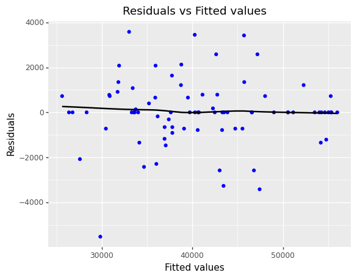

```python
model_final = model9

df = pd.DataFrame({'fitted': model_final.fittedvalues, 'residuals': model_final.resid})
print(pn.ggplot(df, pn.aes(x='fitted', y='residuals')) + \
    pn.geom_point(color='blue') + \
    pn.geom_smooth(se=False) + \
    pn.xlab('Fitted values') + \
    pn.ylab('Residuals') + \
    pn.ggtitle('Residuals vs Fitted values'))
```

In this plot, we can see that residuals are randomly distributed and closer to zero when compared with the previous models. Also, the regression line is horizontal, which means that the variance of the residuals is constant. This plot shows that the model is linear in parameters.

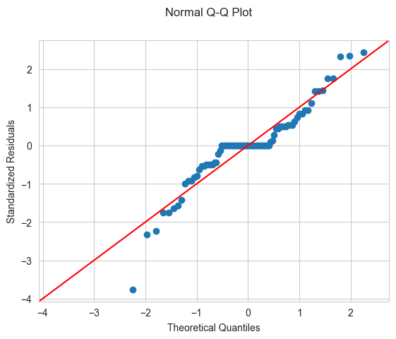

```python
fig = sm.qqplot(model_final.resid, stats.norm, fit=True, line='45')
fig.suptitle('Normal Q-Q Plot')
fig.axes[0].set_xlabel('Theoretical Quantiles')
fig.axes[0].set_ylabel('Standardized Residuals')

plt.show()
```

In this plot, we can see that the points are closer to the line, which means that the residuals are likely to be normally distributed.

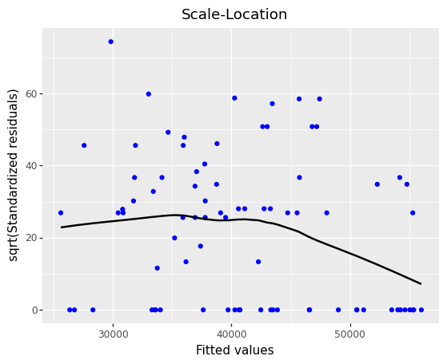

```python
df = pd.DataFrame({'fitted': model_final.fittedvalues, 'sqrt_abs_residuals': abs(model_final.resid)**0.5})
print(pn.ggplot(df, pn.aes(x='fitted', y='sqrt_abs_residuals')) + \
    pn.geom_point(color='blue') + \
    pn.geom_smooth(se=False) + \
    pn.xlab('Fitted values') + \
    pn.ylab('sqrt(Standardized residuals)') + \
    pn.ggtitle('Scale-Location'))
```

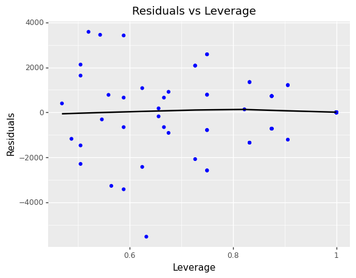

```python
df = pd.DataFrame({'residuals': model_final.resid, 'leverage': OLSInfluence(model_final).hat_matrix_diag})
print(pn.ggplot(df, pn.aes(x='leverage', y='residuals')) + \
    pn.geom_point(color='blue') + \
    pn.geom_smooth(se=False) + \
    pn.xlab('Leverage') + \
    pn.ylab('Residuals') + \
    pn.ggtitle('Residuals vs Leverage'))
```

In this plot, we can see that there are no significant outliers. Also, the points are randomly distributed around the horizontal line.

```python
residuals = model_final.resid
residuals1 = model1.resid
residuals2 = model2.resid
residuals3 = model3.resid
residuals4 = model4.resid
residuals5 = model5.resid
residuals6 = model6.resid
residuals7 = model7.resid
residuals10 = model10.resid

# Calculate the residual standard error
residual_std_error = (sum(residuals**2)/(len(residuals) - model_final.df_model - 1))**0.5
residual_std_error1 = (sum(residuals1**2)/(len(residuals1) - model1.df_model - 1))**0.5
residual_std_error2 = (sum(residuals2**2)/(len(residuals2) - model2.df_model - 1))**0.5
residual_std_error3 = (sum(residuals3**2)/(len(residuals3) - model3.df_model - 1))**0.5
residual_std_error4 = (sum(residuals4**2)/(len(residuals4) - model4.df_model - 1))**0.5
residual_std_error5 = (sum(residuals5**2)/(len(residuals5) - model5.df_model - 1))**0.5
residual_std_error6 = (sum(residuals6**2)/(len(residuals6) - model6.df_model - 1))**0.5
residual_std_error7 = (sum(residuals7**2)/(len(residuals7) - model7.df_model - 1))**0.5
residual_std_error10 = (sum(residuals10**2)/(len(residuals10) - model10.df_model - 1))**0.5

# Print the residual standard error
print("Final model RSE:", residual_std_error)
print("Model 1 RSE:", residual_std_error1)
print("Model 2 RSE", residual_std_error2)
print("Model 3 RSE", residual_std_error3)
print("Model 4 RSE", residual_std_error4)
print("Model 5 RSE", residual_std_error5)
print("Model 6 RSE", residual_std_error6)
print("Model 7 RSE", residual_std_error7)
print("Model 10 RSE", residual_std_error10)
```

```
Final model RSE: 3411.949216151325
Model 1 RSE: 5495.223702094454
Model 2 RSE 4822.328998407842
Model 3 RSE 4901.206496127628
Model 4 RSE 4442.42867973604
Model 5 RSE 4899.327113279934
Model 6 RSE 5151.161734806178
Model 7 RSE 4892.677104707191
Model 10 RSE 3570.053956901149
```

We can see that the RSE of the final model is lower than the RSE of the other models. This means that the final model is better than the other models.

```python
print("Model 1 AIC:", model1.aic)
print("Model 2 AIC:", model2.aic)
print("Model 3 AIC:", model3.aic)
print("Model 4 AIC:", model4.aic)
print("Model 5 AIC:", model5.aic)
print("Model 6 AIC:", model6.aic)
print("Model 7 AIC:", model7.aic)
print("Model 10 AIC:", model10.aic)
print("Final Model (Model 9) AIC:", model_final.aic)
```

```
Model 1 AIC: 1648.9856551638036
Model 2 AIC: 1625.9946145895117
Model 3 AIC: 1627.966990518729
Model 4 AIC: 1594.6687271826142
Model 5 AIC: 1627.9048592027839
Model 6 AIC: 1632.4338431728227
Model 7 AIC: 1627.6848222153758
Model 10 AIC: 1521.1072817741792
Final Model (Model 9) AIC: 1543.1460491261594
```

We can see that the AIC of the final model is lower than the AIC of the other models except Model 10. This means that the final model is better than the other models.

```python
print("Model 1 Adj R2:", model1.rsquared_adj)
print("Model 2 Adj R2:", model2.rsquared_adj)
print("Model 3 Adj R2:", model3.rsquared_adj)
print("Model 4 Adj R2:", model4.rsquared_adj)
print("Model 5 Adj R2:", model5.rsquared_adj)
print("Model 6 Adj R2:", model6.rsquared_adj)
print("Model 7 Adj R2:", model7.rsquared_adj)
print("Model 10 Adj R2:", model10.rsquared_adj)
print("Final Model (Model 9) Adj R2:", model_final.rsquared_adj)
```

```
Model 1 Adj R2: 0.5613964926219361
Model 2 Adj R2: 0.6622347084667436
Model 3 Adj R2: 0.6510948755827032
Model 4 Adj R2: 0.7133563828400262
Model 5 Adj R2: 0.6513624017873942
Model 6 Adj R2: 0.6145999922681339
Model 7 Adj R2: 0.6523081927158365
Model 10 Adj R2: 0.8148810377267766
Final Model (Model 9) Adj R2: 0.8309144618679312
```

We can see that the adjusted R2 of the final model is higher than the adjusted R2 of the other models. This means that the final model is better than the other models.

## Predictions

```python
df = pd.DataFrame({"month": ["AUG"], "day_of_week": ["Monday"], "skies": ["Clear"], 'opponent': ['Pirates'], "bobblehead": ["YES"]})

# Use the predict() function of the fitted model to get the predicted value and prediction interval for the new observation
pred_results = model_final.get_prediction(df).summary_frame(alpha=0.05)

# Print the predicted value and prediction interval
print("Predicted value and 90% prediction interval:")
print(pred_results[["mean", "mean_ci_lower", "mean_ci_upper"]])
```

```
Predicted value and 90% prediction interval:
           mean  mean_ci_lower  mean_ci_upper
0  42356.464335   29592.924756   55120.003914
```

```python
df = pd.DataFrame({"month": ["AUG"], "day_of_week": ["Monday"], "skies": ["Clear"], 'opponent': ['Pirates'], "bobblehead": ["NO"]})

# Use the predict() function of the fitted model to get the predicted value and prediction interval for the new observation
pred_results = model_final.get_prediction(df).summary_frame(alpha=0.05)

# Print the predicted value and prediction interval
print("Predicted value and 90% prediction interval:")
print(pred_results[["mean", "mean_ci_lower", "mean_ci_upper"]])
```

```
Predicted value and 90% prediction interval:
           mean  mean_ci_lower  mean_ci_upper
0  34600.594229   23538.649083   45662.539375
```

These results are consistent with our expectations. We can see that the **attendance is higher when bobbleheads are distributed**.

```python
df = pd.DataFrame({"month": ["AUG"], "day_of_week": ["Sunday"], "skies": ["Clear"], 'opponent': ['Pirates'], "bobblehead": ["YES"]})

# Use the predict() function of the fitted model to get the predicted value and prediction interval for the new observation
pred_results = model_final.get_prediction(df).summary_frame(alpha=0.05)

# Print the predicted value and prediction interval
print("Predicted value and 90% prediction interval:")
print(pred_results[["mean", "mean_ci_lower", "mean_ci_upper"]])
```

```
Predicted value and 90% prediction interval:
           mean  mean_ci_lower  mean_ci_upper
0  53142.876289   36639.929149   69645.823428
```

```python
df = pd.DataFrame({"month": ["AUG"], "day_of_week": ["Sunday"], "skies": ["Clear"], 'opponent': ['Pirates'], "bobblehead": ["NO"]})

# Use the predict() function of the fitted model to get the predicted value and prediction interval for the new observation
pred_results = model_final.get_prediction(df).summary_frame(alpha=0.05)

# Print the predicted value and prediction interval
print("Predicted value and 90% prediction interval:")
print(pred_results[["mean", "mean_ci_lower", "mean_ci_upper"]])
```

```
Predicted value and 90% prediction interval:
           mean  mean_ci_lower  mean_ci_upper
0  45387.006183   30527.734028   60246.278337
```

These results are also consistent with our expectations. We can see that the **attendance is higher when bobbleheads are distributed**.

```python
df = pd.DataFrame({"month": ["AUG"], "day_of_week": ["Sunday"], "skies": ["Clear"], 'opponent': ['Braves'], "bobblehead": ["YES"]})

# Use the predict() function of the fitted model to get the predicted value and prediction interval for the new observation
pred_results = model_final.get_prediction(df).summary_frame(alpha=0.05)

# Print the predicted value and prediction interval
print("Predicted value and 90% prediction interval:")
print(pred_results[["mean", "mean_ci_lower", "mean_ci_upper"]])
```

```
Predicted value and 90% prediction interval:
           mean  mean_ci_lower  mean_ci_upper
0  48311.376289   31992.061292   64630.691285
```

```python
df = pd.DataFrame({"month": ["AUG"], "day_of_week": ["Sunday"], "skies": ["Clear"], 'opponent': ['Braves'], "bobblehead": ["NO"]})

# Use the predict() function of the fitted model to get the predicted value and prediction interval for the new observation
pred_results = model_final.get_prediction(df).summary_frame(alpha=0.05)

# Print the predicted value and prediction interval
print("Predicted value and 90% prediction interval:")
print(pred_results[["mean", "mean_ci_lower", "mean_ci_upper"]])
```

```
Predicted value and 90% prediction interval:
           mean  mean_ci_lower  mean_ci_upper
0  40555.506183   25653.550683   55457.461682
```

These results are also consistent with our expectations. We can see that the **attendance is higher when bobbleheads are distributed**.

## Conclusion

Using linear regression techniques with tools available in Python libraries, we were able to build a model that predicts the attendance of a baseball game with a high degree of accuracy. We performed a stepwise selection to find the best model. We found that the final model is better than the other models by looking at AIC, Adj R2, and RSE values. Our model assumes that the attendance is a function of the month, day of the week, the opponent, the weather, and whether bobbleheads are distributed. After tuning the data model, we predicted the attendance to several games. We found that the attendance is higher when bobbleheads are distributed.